# exam_1

James Hutt

21/02/2020

## Question 1

The highest emissions are from the country China.

The number of countries that have neither ratified nor approved of the treaty is 12. (Acceptance and accession do not count as approval).

The longest number of days between signature and ratification (for a country that has successfully ratified) is 1384 days.

The number of ratifying countries whose name ends with “stan” is 7.

In 1960, the country with the highest emissions (per capita) was Luxembourg.

The average emissions in 2000 was 4.58 metric tons per capita.

## Question 2

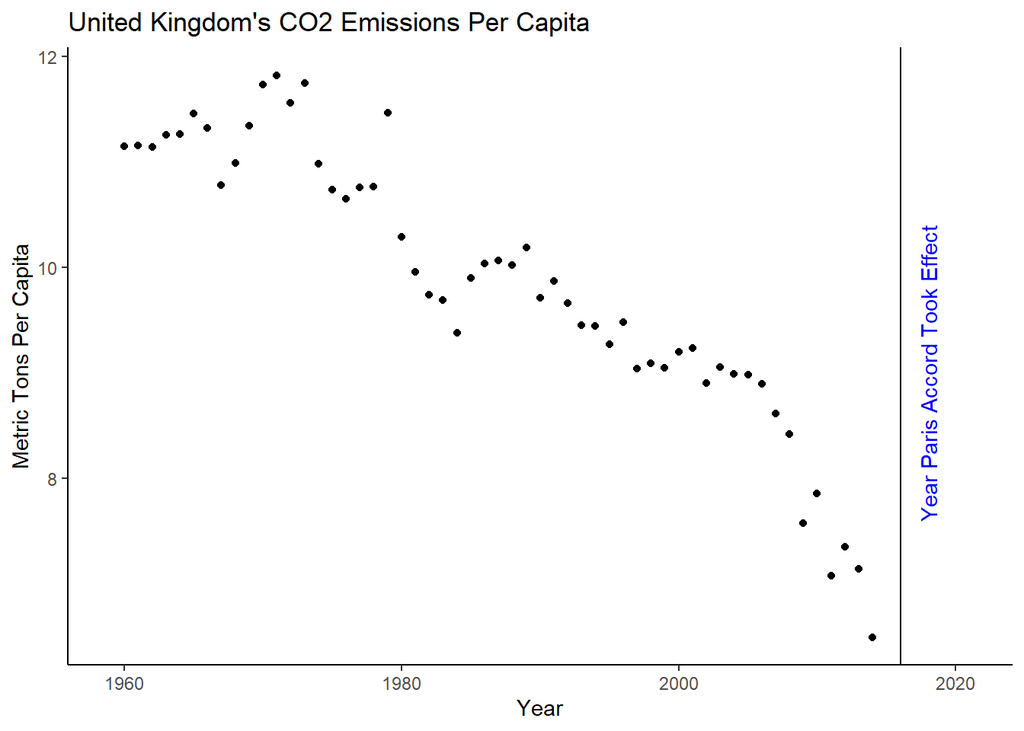

Q2 note: Following the advice from the [Piazza](https://piazza.com/class/k5y1jx0s5ibe1?cid=204) post I have tried to show that (1) a tibble can be created which is joined on two variables and (2) that I can present data effectively from across the two data sets. The tibble joined on 2 variables is included in the Rmd file but not used to produce a chart, because the data is quite limited as far as comparison goes. Instead I have produced a chart analgous to the Mexico chart given as an example which dynamically pulls the year of ratification from the Paris data set and annotates this on the WB_CO2 data as a vertical line.

## Question 3

RCM Setup for Experiment with Ratified Countries<sup>1</sup>

Selected Examples of Treatment Assignment

| Country | Treatment | Control | Potential Outcomes Under Control | Potential Outcomes Under Treatment |
| --- | --- | --- | --- | --- |
| Albania | 1 | 0 | ? | Change in Emissions in 1y following treatment |
| Andorra | 1 | 0 | ? | Change in Emissions in 1y following treatment |
| Bahrain | 0 | 1 | Change in Emissions in 1y following treatment | ? |
| Belize | 0 | 1 | Change in Emissions in 1y following treatment | ? |
| Egypt | 1 | 0 | ? | Change in Emissions in 1y following treatment |
| France | 0 | 1 | Change in Emissions in 1y following treatment | ? |
| India | 1 | 0 | ? | Change in Emissions in 1y following treatment |
| Oman | 1 | 0 | ? | Change in Emissions in 1y following treatment |
| Pakistan | 0 | 1 | Change in Emissions in 1y following treatment | ? |
| Uganda | 1 | 0 | ? | Change in Emissions in 1y following treatment |
| United Republic of Tanzania | 1 | 0 | ? | Change in Emissions in 1y following treatment |
| Zimbabwe | 0 | 1 | Change in Emissions in 1y following treatment | ? |

<sup>*1*</sup> Treatment is a $1b fund to fight climate change. Assignment is by first letter of country name

Explanation: This table shows a framework to determine the causal effect of giving a country 1 billion dollars on subsequent emissions. We cannot observe countries under both cases – treatment and no treatment – because the effects would be cumulative, instead we “randomly” assign countries to the two treatments. We assume that the average response to treatment will be the same, however we randomly allocate countries between the two groups. By observing the difference in responses between the two groups we suggest that it was the treatment which caused the variation in outcome. Here the outcome is the change in emissions in the year following treatment (or lack of treatment). The “?“ represent data it will be impossible to collect – we will never know how, eg Albania, would have reacted in the control case, because it has received the money. The assignment mechanism was: countries which start with a vowel get the money. Whilst this process seems random, it would be straightforward to actually randomly assign countries, neglecting the need to check whether names starting with vowels are correlated with some omitted variable, which is possible! Thus, a better assignment mechanism would be a (pseudo) random binary generator for each country.